> **Tip**: Welcome to the Investigate a Dataset project! You will find tips in quoted sections like this to help organize your approach to your investigation. Before submitting your project, it will be a good idea to go back through your report and remove these sections to make the presentation of your work as tidy as possible. First things first, you might want to double-click this Markdown cell and change the title so that it reflects your dataset and investigation.

# Project: TMDb_Movies Data Analysis

- Introduction
- Data Wrangling
- Exploratory Data Analysis
- Conclusions

## Introduction

> **Tip**: In this section of the report, provide a brief introduction to the dataset you've selected for analysis. At the end of this section, describe the questions that you plan on exploring over the course of the report. Try to build your report around the analysis of at least one dependent variable and three independent variables. If you're not sure what questions to ask, then make sure you familiarize yourself with the dataset, its variables and the dataset context for ideas of what to explore.

In this project we will be analyzin a data set containing information about 10000+ movies collected from The Movie Database(TMDb).

Upon analysis, we wil try to answer following questions:

1) Which genres are most popular?

> If you haven't yet selected and downloaded your data, make sure you do that first before coming back here. In order to work with the data in this workspace, you also need to upload it to the workspace. To do so, click on the jupyter icon in the upper left to be taken back to the workspace directory. There should be an 'Upload' button in the upper right that will let you add your data file(s) to the workspace. You can then click on the .ipynb file name to come back here.

```python
import pandas as pd
import matplotlib.pyplot as plt
import numpy as np
import seaborn as sns
%matplotlib inline
```

```python
df=pd.read_csv('movies.csv')
df.head(1)
```

|  | id | imdb_id | popularity | budget | revenue | original_title | cast | homepage | director | tagline | ... | overview | runtime | genres | production_companies | release_date | vote_count | vote_average | release_year | budget_adj | revenue_adj |
| --- | --- | --- | --- | --- | --- | --- | --- | --- | --- | --- | --- | --- | --- | --- | --- | --- | --- | --- | --- | --- | --- |
| 0 | 135397 | tt0369610 | 32.985763 | 150000000 | 1513528810 | Jurassic World | Chris Pratt\|Bryce Dallas Howard\|Irrfan Khan\|Vi... | http://www.jurassicworld.com/ | Colin Trevorrow | The park is open. | ... | Twenty-two years after the events of Jurassic ... | 124 | Action\|Adventure\|Science Fiction\|Thriller | Universal Studios\|Amblin Entertainment\|Legenda... | 6/9/15 | 5562 | 6.5 | 2015 | 1.379999e+08 | 1.392446e+09 |

1 rows × 21 columns

## Data Wrangling

> **Tip**: In this section of the report, you will load in the data, check for cleanliness, and then trim and clean your dataset for analysis. Make sure that you document your steps carefully and justify your cleaning decisions.

### General Properties

```python
# Load your data and print out a few lines. Perform operations to inspect data
#   types and look for instances of missing or possibly errant data.
df.info()
```

```
<class 'pandas.core.frame.DataFrame'>
RangeIndex: 10866 entries, 0 to 10865
Data columns (total 21 columns):
id                      10866 non-null int64
imdb_id                 10856 non-null object
popularity              10866 non-null float64
budget                  10866 non-null int64
revenue                 10866 non-null int64
original_title          10866 non-null object
cast                    10790 non-null object
homepage                2936 non-null object
director                10822 non-null object
tagline                 8042 non-null object
keywords                9373 non-null object
overview                10862 non-null object
runtime                 10866 non-null int64
genres                  10843 non-null object
production_companies    9836 non-null object
release_date            10866 non-null object
vote_count              10866 non-null int64
vote_average            10866 non-null float64
release_year            10866 non-null int64
budget_adj              10866 non-null float64
revenue_adj             10866 non-null float64
dtypes: float64(4), int64(6), object(11)
memory usage: 1.7+ MB
```

> **Tip**: You should *not* perform too many operations in each cell. Create cells freely to explore your data. One option that you can take with this project is to do a lot of explorations in an initial notebook. These don't have to be organized, but make sure you use enough comments to understand the purpose of each code cell. Then, after you're done with your analysis, create a duplicate notebook where you will trim the excess and organize your steps so that you have a flowing, cohesive report.

> **Tip**: Make sure that you keep your reader informed on the steps that you are taking in your investigation. Follow every code cell, or every set of related code cells, with a markdown cell to describe to the reader what was found in the preceding cell(s). Try to make it so that the reader can then understand what they will be seeing in the following cell(s).

```python
df.drop(['id', 'imdb_id', 'homepage', 'tagline', 'keywords', 'overview'], axis=1, inplace=True)

df.shape
```

```
(10866, 15)
```

Data type of 'release_date' is object, so changing it into date format.

```python
df.release_date=pd.to_datetime(df['release_date'])
```

```python
df.info()
```

```
<class 'pandas.core.frame.DataFrame'>
RangeIndex: 10866 entries, 0 to 10865
Data columns (total 15 columns):
popularity              10866 non-null float64
budget                  10866 non-null int64
revenue                 10866 non-null int64
original_title          10866 non-null object
cast                    10790 non-null object
director                10822 non-null object
runtime                 10866 non-null int64
genres                  10843 non-null object
production_companies    9836 non-null object
release_date            10866 non-null datetime64[ns]
vote_count              10866 non-null int64
vote_average            10866 non-null float64
release_year            10866 non-null int64
budget_adj              10866 non-null float64
revenue_adj             10866 non-null float64
dtypes: datetime64[ns](1), float64(4), int64(5), object(5)
memory usage: 1.2+ MB
```

```python
df.describe()
```

|  | popularity | budget | revenue | runtime | vote_count | vote_average | release_year | budget_adj | revenue_adj |
| --- | --- | --- | --- | --- | --- | --- | --- | --- | --- |
| count | 10866.000000 | 1.086600e+04 | 1.086600e+04 | 10866.000000 | 10866.000000 | 10866.000000 | 10866.000000 | 1.086600e+04 | 1.086600e+04 |
| mean | 0.646441 | 1.462570e+07 | 3.982332e+07 | 102.070863 | 217.389748 | 5.974922 | 2001.322658 | 1.755104e+07 | 5.136436e+07 |
| std | 1.000185 | 3.091321e+07 | 1.170035e+08 | 31.381405 | 575.619058 | 0.935142 | 12.812941 | 3.430616e+07 | 1.446325e+08 |
| min | 0.000065 | 0.000000e+00 | 0.000000e+00 | 0.000000 | 10.000000 | 1.500000 | 1960.000000 | 0.000000e+00 | 0.000000e+00 |
| 25% | 0.207583 | 0.000000e+00 | 0.000000e+00 | 90.000000 | 17.000000 | 5.400000 | 1995.000000 | 0.000000e+00 | 0.000000e+00 |
| 50% | 0.383856 | 0.000000e+00 | 0.000000e+00 | 99.000000 | 38.000000 | 6.000000 | 2006.000000 | 0.000000e+00 | 0.000000e+00 |
| 75% | 0.713817 | 1.500000e+07 | 2.400000e+07 | 111.000000 | 145.750000 | 6.600000 | 2011.000000 | 2.085325e+07 | 3.369710e+07 |
| max | 32.985763 | 4.250000e+08 | 2.781506e+09 | 900.000000 | 9767.000000 | 9.200000 | 2015.000000 | 4.250000e+08 | 2.827124e+09 |

Now let's check for duplicates in our data set.

```python
df.duplicated().sum()
```

```
1
```

There's a single duplicate so we'll remove it.

```python
df.drop_duplicates(keep = 'first', inplace = True)
```

```python
df.shape
```

```
(10865, 15)
```

Now, lets figure out which movies have a value of '0' in their budget or revenue, and then deleting those movies from database. First we will replace the value of '0' with NaN and then dropping the rows which had NaN values in them.

```python
rows=['budget', 'revenue','budget_adj','revenue_adj']
df[rows] = df[rows].replace(0, np.NaN)
df.dropna(subset=rows, inplace=True)
df.shape
```

```
(3854, 15)
```

```python
df.head(1)
```

|  | popularity | budget | revenue | original_title | cast | director | runtime | genres | production_companies | release_date | vote_count | vote_average | release_year | budget_adj | revenue_adj |
| --- | --- | --- | --- | --- | --- | --- | --- | --- | --- | --- | --- | --- | --- | --- | --- |
| 0 | 32.985763 | 150000000.0 | 1.513529e+09 | Jurassic World | Chris Pratt\|Bryce Dallas Howard\|Irrfan Khan\|Vi... | Colin Trevorrow | 124 | Action\|Adventure\|Science Fiction\|Thriller | Universal Studios\|Amblin Entertainment\|Legenda... | 2015-06-09 | 5562 | 6.5 | 2015 | 1.379999e+08 | 1.392446e+09 |

```python
df.describe()
```

|  | popularity | budget | revenue | runtime | vote_count | vote_average | release_year | budget_adj | revenue_adj |
| --- | --- | --- | --- | --- | --- | --- | --- | --- | --- |
| count | 3854.000000 | 3.854000e+03 | 3.854000e+03 | 3854.000000 | 3854.000000 | 3854.000000 | 3854.000000 | 3.854000e+03 | 3.854000e+03 |
| mean | 1.191554 | 3.720370e+07 | 1.076866e+08 | 109.220291 | 527.720291 | 6.168163 | 2001.261028 | 4.423999e+07 | 1.370647e+08 |
| std | 1.475162 | 4.220822e+07 | 1.765393e+08 | 19.922820 | 879.956821 | 0.794920 | 11.282575 | 4.480925e+07 | 2.161114e+08 |
| min | 0.001117 | 1.000000e+00 | 2.000000e+00 | 15.000000 | 10.000000 | 2.200000 | 1960.000000 | 9.693980e-01 | 2.370705e+00 |
| 25% | 0.462368 | 1.000000e+07 | 1.360003e+07 | 95.000000 | 71.000000 | 5.700000 | 1995.000000 | 1.309053e+07 | 1.835735e+07 |
| 50% | 0.797511 | 2.400000e+07 | 4.480000e+07 | 106.000000 | 204.000000 | 6.200000 | 2004.000000 | 3.001611e+07 | 6.173068e+07 |
| 75% | 1.368324 | 5.000000e+07 | 1.242125e+08 | 119.000000 | 580.000000 | 6.700000 | 2010.000000 | 6.061307e+07 | 1.632577e+08 |
| max | 32.985763 | 4.250000e+08 | 2.781506e+09 | 338.000000 | 9767.000000 | 8.400000 | 2015.000000 | 4.250000e+08 | 2.827124e+09 |

[output not shown]

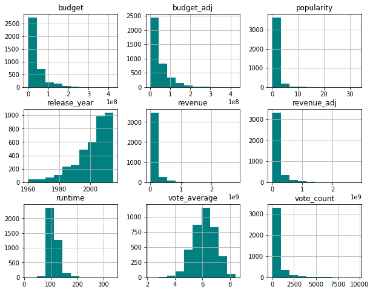

```python
df.hist(figsize=(10,8), color='teal')
```

From histograms we can nottice that:

2) The histogram of vote_average is normally distributed.

3) The histogram of release_year is left-skewed, which means the movies were released more over the years. There's a gradual gradual increase in the movie release after the year 1980 and after 2000 it is at the peak.

# Exploratory Data Analysis

Now first lets check if we have any movie with a runtime value of 0. If we have any, we will replace with NaN.

```python
df['runtime'] = df['runtime'].replace(0, np.NaN)
```

Creating a column named Profit to store the profits of the movies earned over the years.

We calculated profit using formula: Profit= Revenue - Budget.

```python
df.insert(2, 'profit',df['revenue']-df['budget'])
```

```python
df['profit'].describe()
```

```
count    3.854000e+03
mean     7.048292e+07
std      1.506195e+08
min     -4.139124e+08
25%     -1.321535e+06
50%      2.002019e+07
75%      8.170331e+07
max      2.544506e+09
Name: profit, dtype: float64
```

# Research Question 1:

**How many movies were released per year?**

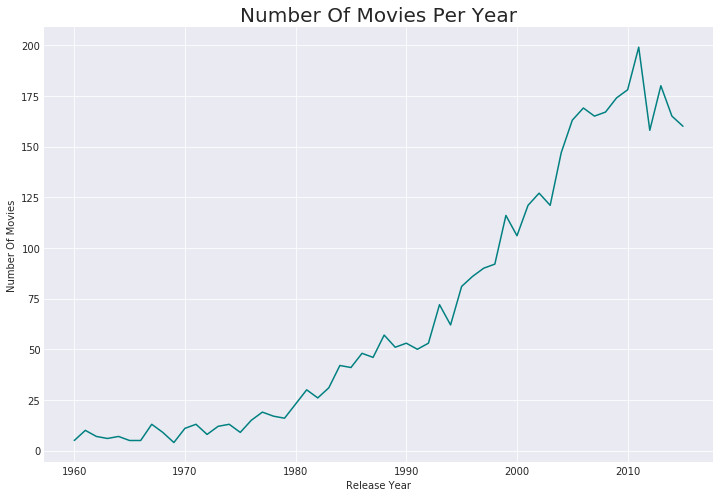

```python
#we know that popularity column has no nulls
#so use it for counting the number of movies
ax = df.groupby('release_year')['popularity'].count().plot(figsize=(12, 8), color='teal')
#set titles and labels
plt.title('Number Of Movies Per Year', size=20)
plt.ylabel('Number Of Movies')
plt.xlabel("Release Year" );
```

*Lets plot a histogram and boxplot to see the runtime distribution of movies over these years.

**A) Histogram**

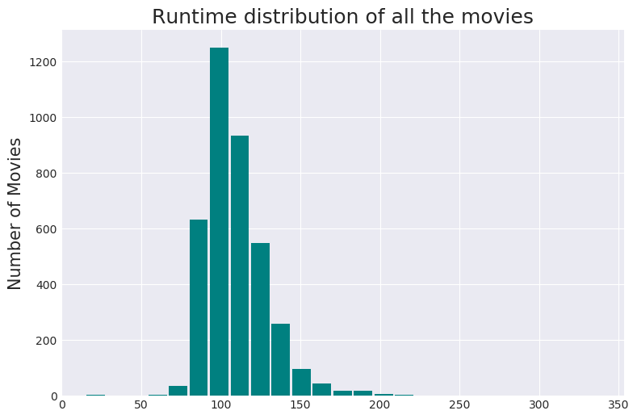

```python
#Plotting Histogram.
sns.set_style('darkgrid')

#chaging the label size, this will change the size of all plots that we plot from now!
plt.rc('xtick', labelsize = 10)
plt.rc('ytick', labelsize = 10)

plt.figure(figsize=(9,6), dpi = 100)
plt.ylabel('Number of Movies', fontsize=15)
plt.title('Runtime distribution of all the movies', fontsize=18)

#giving a histogram plot
plt.hist(df['runtime'], rwidth = 0.9, bins=25, color='teal')
#displays the plot
plt.show()
```

**B) Boxplot**

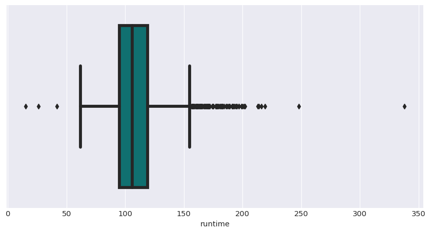

```python
plt.figure(figsize=(10,5), dpi = 105)
sns.set_style('darkgrid')
#plotting box plot
sns.boxplot(df['runtime'], linewidth = 4, color='teal')
#showing the plot
plt.show()
```

### In which year we had most movies making profit?

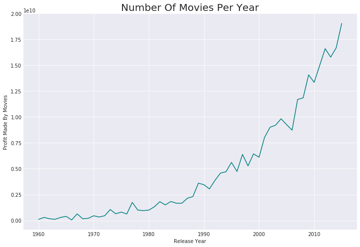

```python
#we know that popularity column has no nulls
#so use it for counting the number of movies
ax = df.groupby('release_year')['profit'].sum().plot(figsize=(12, 8), color='teal')
#set titles and labels
plt.title('Number Of Movies Per Year', size=20)
plt.ylabel('Profit Made By Movies')
plt.xlabel("Release Year" );
```

**Popularity Vs Vote_Count regression plot depicting the vote counts and popularity of the movies.**

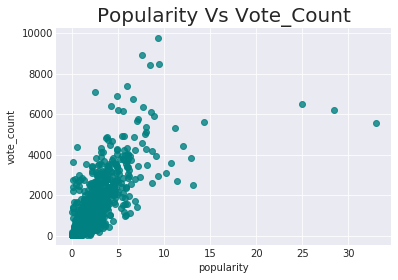

```python
x=sns.regplot(data=df, x='popularity' ,y='vote_count', fit_reg=False, color='teal').set_title('Popularity Vs Vote_Count', size=20)
```

## Research Question 2 : What kind of properties are associated with highly profitable movies?

Befor answering to this question, we need to create a dataset of movies who made profit of 100M. As these movies have grossed such a humungous amount, we will analyse the common trends between them.

```python
profit_data = df.query('profit >= 100000000')

#reindexing new dataframe
profit_data.index = range(len(profit_data))
#will initialize dataframe from 1 instead of 0
profit_data.index = profit_data.index + 1

#showing the dataset
profit_data.head(2)
```

|  | popularity | budget | profit | revenue | original_title | cast | director | runtime | genres | production_companies | release_date | vote_count | vote_average | release_year | budget_adj | revenue_adj |
| --- | --- | --- | --- | --- | --- | --- | --- | --- | --- | --- | --- | --- | --- | --- | --- | --- |
| 1 | 32.985763 | 150000000.0 | 1.363529e+09 | 1.513529e+09 | Jurassic World | Chris Pratt\|Bryce Dallas Howard\|Irrfan Khan\|Vi... | Colin Trevorrow | 124 | Action\|Adventure\|Science Fiction\|Thriller | Universal Studios\|Amblin Entertainment\|Legenda... | 2015-06-09 | 5562 | 6.5 | 2015 | 1.379999e+08 | 1.392446e+09 |
| 2 | 28.419936 | 150000000.0 | 2.284364e+08 | 3.784364e+08 | Mad Max: Fury Road | Tom Hardy\|Charlize Theron\|Hugh Keays-Byrne\|Nic... | George Miller | 120 | Action\|Adventure\|Science Fiction\|Thriller | Village Roadshow Pictures\|Kennedy Miller Produ... | 2015-05-13 | 6185 | 7.1 | 2015 | 1.379999e+08 | 3.481613e+08 |

```python
profit_data.shape
```

```
(826, 16)
```

In 100M club, we only have 826 movies, whereas we have a total of 3854 enteries in our dataset.

```python
#A common fucntion created to reduce the work of writing the code repeatedly.
#The function will take any column as argument from which data is to be extracted and keep the track of its count.

def extract(column_name):
    #will take a column, and separate the string by '|'
    all_data = profit_data[column_name].str.cat(sep = '|')

    #giving pandas series and storing the values separately
    all_data = pd.Series(all_data.split('|'))

    #this will us value in descending order
    count = all_data.value_counts(ascending = False)

    return count
```

#### Q) Which actors were appeared the most?

```python
c=extract('cast')
c.head(2)
```

```
Tom Cruise    23
Tom Hanks     19
dtype: int64
```

The list of artists which has appeared the most in our 100M club. Tom Cruise has the most number of appearence in the most profitable movies.

#### Q) Which are the successful genres in profiatble movies?

```python
a=extract('genres')
a.head()
```

```
Action       317
Comedy       299
Adventure    278
Drama        264
Thriller     233
dtype: int64
```

Visualizing the plot for most successful genres.

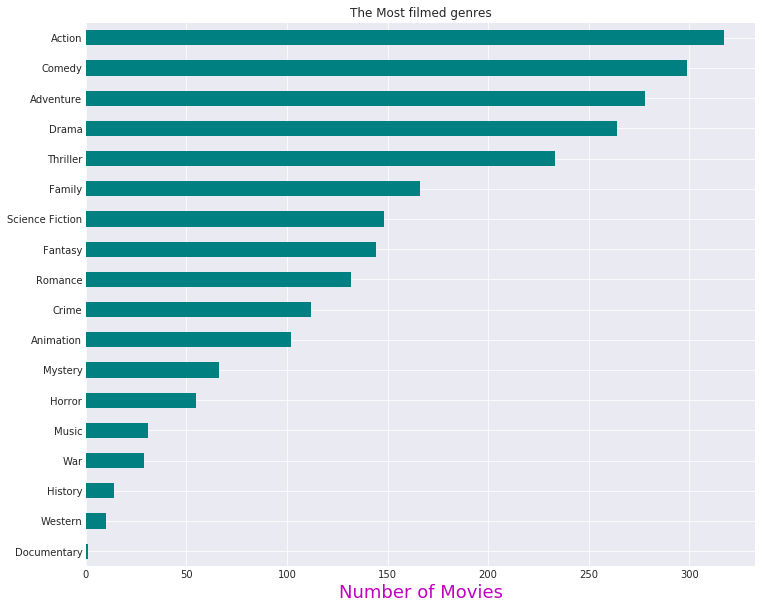

```python
a.sort_values(ascending =True, inplace=True)
ax = a.plot.barh(color='teal')
ax.set(title = 'The Most filmed genres')

#x-label
ax.set_xlabel('Number of Movies', color = 'm', fontsize = '18')

#giving the figure size(width, height)
ax.figure.set_size_inches(12, 10)

#shwoing the plot
plt.show()
```

```python
dirx = extract('director')
dirx.head()
```

```
Steven Spielberg    22
Robert Zemeckis     10
Michael Bay          8
Ridley Scott         7
David Fincher        7
dtype: int64
```

#### Q) Top 10 production companies which produced most number of profitable movies:

```python
pc=extract('production_companies').head(10)
pc
```

```
Warner Bros.                              102
Universal Pictures                         99
Paramount Pictures                         87
Twentieth Century Fox Film Corporation     82
Walt Disney Pictures                       58
Columbia Pictures                          54
New Line Cinema                            39
Amblin Entertainment                       34
Touchstone Pictures                        32
Relativity Media                           31
dtype: int64
```

### Visualization for top 10 production companies:

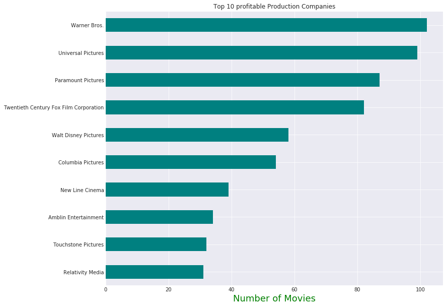

```python
pc.sort_values(ascending =True, inplace=True)
ax = pc.plot.barh(color='teal')
ax.set(title = 'Top 10 profitable Production Companies')

#x-label
ax.set_xlabel('Number of Movies', color = 'g', fontsize = '18')

#giving the figure size(width, height)
ax.figure.set_size_inches(12, 10)

#shwoing the plot
plt.show()
```

Average budget of movie:

```python
profit_data['budget'].mean()
```

```
74469572.77602905
```

Average revenue of movie:

```python
profit_data['revenue'].mean()
```

```
345328046.81961256
```

Average profits earned by the movie in 100M club:

```python
profit_data['profit'].mean()
```

```
270858474.04358351
```

Average Runtime:

```python
profit_data['runtime'].mean()
```

```
115.62832929782083
```

## Conclusions

**Limitations**

- There was a lot of missing data in the dataset.
- In the dataset, some of the fields were '0' and I can't conclude exact results based on that data, so I dropped those field. I feel that the results are not totally reliable as we calculated it with some voids present in our dataset, but it can give us fairly rough idea about how the trends would look like.

> Before you submit your project, you need to create a .html or .pdf version of this notebook in the workspace here. To do that, run the code cell below. If it worked correctly, you should get a return code of 0, and you should see the generated .html file in the workspace directory (click on the orange Jupyter icon in the upper left).

> Alternatively, you can download this report as .html via the **File** > **Download as** submenu, and then manually upload it into the workspace directory by clicking on the orange Jupyter icon in the upper left, then using the Upload button.

> Once you've done this, you can submit your project by clicking on the "Submit Project" button in the lower right here. This will create and submit a zip file with this .ipynb doc and the .html or .pdf version you created. Congratulations!

```python
from subprocess import call
call(['python', '-m', 'nbconvert', 'Investigate_a_Dataset.ipynb'])
```